# Regression_hw1

2023-04-27

```r
Sys.setlocale(locale = 'persian')
```

```
## [1] ""
```

```r
library(data.table)
library(ggplot2)
```

First lets read the csv file using `fread` and look at its data.

```r
d = fread('/Users/lachinnaghashyar/Downloads/iranprovs_mortality_monthly.csv', encoding = 'UTF-8')
d
```

```
##            y  m           prov sex age_group   n
##      1: 1389 12 آذربايجان شرقي  زن         0 121
##      2: 1389 12 آذربايجان شرقي  زن     01-04 568
##      3: 1389 12 آذربايجان شرقي  زن     05-09 331
##      4: 1389 12 آذربايجان شرقي  زن     10-14 190
##      5: 1389 12 آذربايجان شرقي  زن     15-19 185
##     ---
## 196598: 1401  2            یزد مرد     75-79  21
## 196599: 1401  2            یزد مرد     80-84  21
## 196600: 1401  2            یزد مرد     85-89  30
## 196601: 1401  2            یزد مرد     90-94  25
## 196602: 1401  2            یزد مرد       95+  10
```

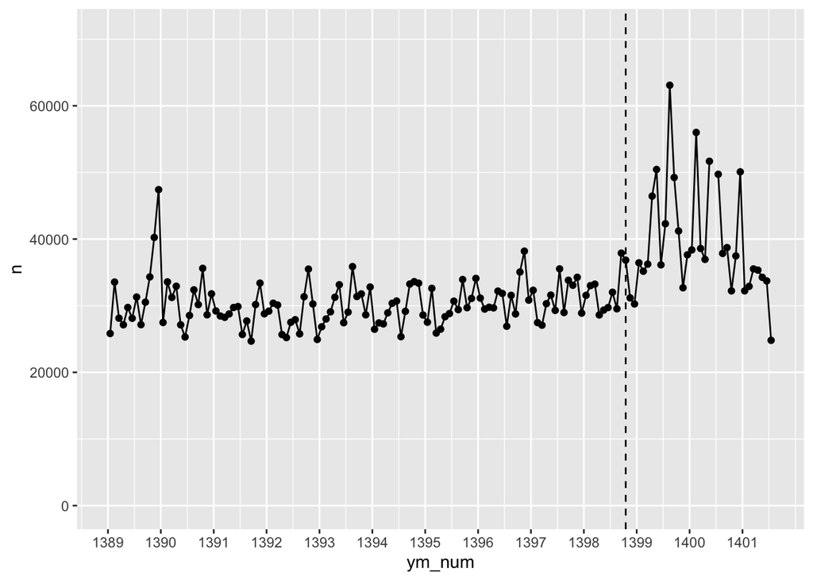

```r
d$ym_num = d$y + d$m / 12 - 1/24 # combine year and month fields in to one field

ds = d[, .(n = sum(n)), .(y, m, ym_num)] # we want to sum the total death based on year and month

ggplot(ds, aes(ym_num, n))+
  geom_line()+
  geom_point()+
  scale_x_continuous(breaks = 1389:1401)+
  scale_y_continuous(limits = c(0, 71000))+
  geom_vline(xintercept = 1398 + 10/12 -1/24, linetype = 'dashed')
```

## Q1

First lets have total death based on both year, month and province.

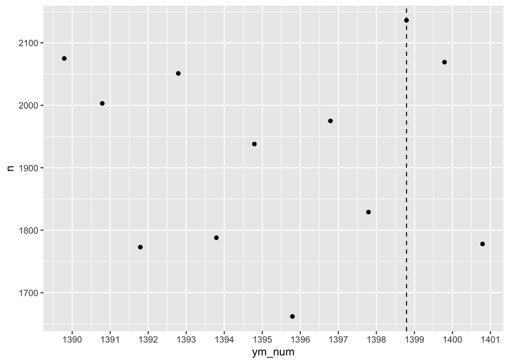

```r
ds = d[, .(n = sum(n)), .(y, m, ym_num, prov)]

M = 10 # month
PROV = unique(ds$prov)[13] #province
dsm = ds[prov == PROV & m == M,] # have it for a fixed province and month

ggplot(dsm, aes(ym_num, n))+
 # geom_line()+
  geom_point()+
  scale_x_continuous(breaks = 1389:1401)+
  geom_vline(xintercept = 1398 + 10/12 -1/24, linetype = 'dashed')
```

If we fit a line on all the data points, then the line will not be accurate. to avoid dealing with non-linear patterns we only look at the last 5 years

```r
ym_num_covid = 1398 + 10/12 - 1/24 # time covid starts (however, we are not also that sure about this in every place)
ym_num_start = ym_num_covid - 5

dsm = dsm[ym_num > ym_num_start]

dsm2fit = dsm[ym_num < ym_num_covid]

fit = lm(n ~ ym_num, dsm2fit)
summary(fit)
```

```
##
## Call:
## lm(formula = n ~ ym_num, data = dsm2fit)
##
## Residuals:
##      1      2      3      4
##   84.9 -189.7  124.7  -19.9
##
## Coefficients:
##             Estimate Std. Error t value Pr(>|t|)
## (Intercept)   3805.8   107378.6   0.035    0.975
## ym_num          -1.4       76.9  -0.018    0.987
##
## Residual standard error: 172 on 2 degrees of freedom
## Multiple R-squared:  0.0001657,  Adjusted R-squared:  -0.4998
## F-statistic: 0.0003314 on 1 and 2 DF,  p-value: 0.9871
```

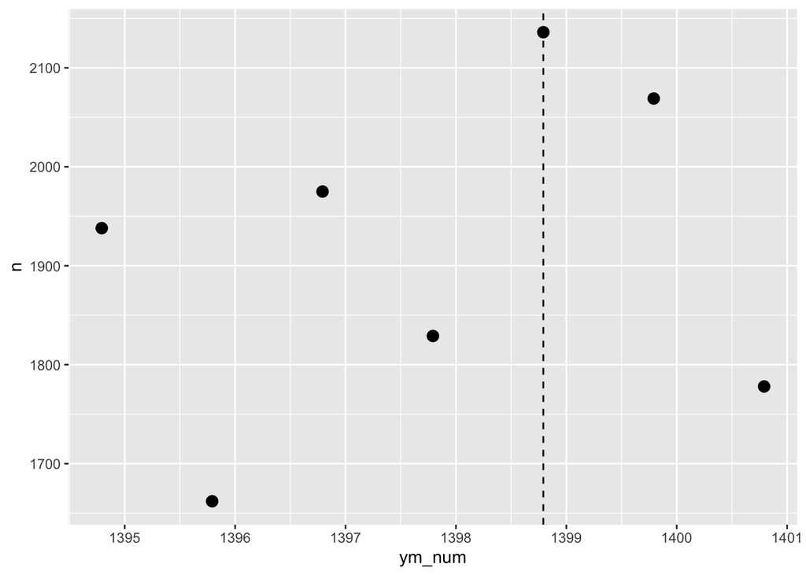

```r
ggplot(dsm, aes(ym_num, n))+
  geom_point(size=3)+
  scale_x_continuous(breaks = 1389:1401)+
  geom_vline(xintercept = 1398 + 10/12 -1/24, linetype = 'dashed')
```

However, the p-value is large and we can calculate the average and variance, then we can detect the outliers. Ususually, we should avoid the ones with large p-values.

```r
predict(fit ,dsm)
```

```
##      1      2      3      4      5      6      7
## 1853.1 1851.7 1850.3 1848.9 1847.5 1846.1 1844.7
```

In order to detect the outliers and excess mortality, we can calculate the differneces of years after 1398 with the predicted values on the line. If this difference is larger than a particular threshold wich can be determined using the variance, then we can report it as a positive excess mortality.

We are goinig to study the data based on different factors including month, province and age groups (not but less such as 3 groups) separately. Sex is not a concern here and we are going to assume different sex groups (f/m) do not differ from each other drastically.

We are going to have separete for loops for each of these factors and see if we can detect an excess mortality or not. (using the predicted value, real value and sigma as described above)

In order to be able to compare different provinces with different populations, we can divide the population by the total number.

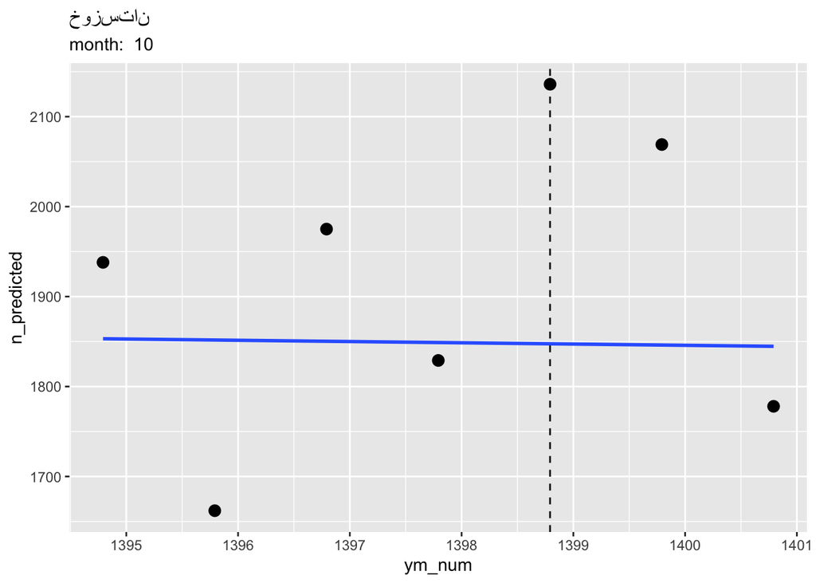

```r
dsm$n_predicted = predict(fit ,dsm)

ggplot(dsm)+
  geom_smooth(aes(ym_num, n_predicted), method = 'lm')+
  geom_point(aes(ym_num, n), size = 3)+
  scale_x_continuous(breaks = 1389:1401)+
  geom_vline(xintercept = 1398 + 10/12 -1/24, linetype = 'dashed')+
  ggtitle(label = PROV, subtitle = paste('month: ', M))
```

We extract the provinces and months from data:

```r
provinces = unique(d$prov)
ds_corona = ds[ym_num >= ym_num_covid]
months = sort(unique(ds_corona$ym_num), decreasing = F)

provinces
```

```
##  [1] "آذربايجان شرقي"      "آذربايجان غربی"      "اردبیل"
##  [4] "اصفهان"              "البرز"               "ایلام"
##  [7] "بوشهر"               "تهران"               "چهارمحال و بختیاری"
## [10] "خراسان جنوبی"        "خراسان رضوی"         "خراسان شمالی"
## [13] "خوزستان"             "زنجان"               "سمنان"
## [16] "سیستان و بلوچستان"   "فارس"                "قزوین"
## [19] "قم"                  "کردستان"             "کرمان"
## [22] "کرمانشاه"            "کهگیلویه و بویراحمد" "گلستان"
## [25] "گیلان"               "لرستان"              "مازندران"
## [28] "مرکزی"               "هرمزگان"             "همدان"
## [31] "یزد"
```

```r
months
```

```
##  [1] 1398.792 1398.875 1398.958 1399.042 1399.125 1399.208 1399.292 1399.375
##  [9] 1399.458 1399.542 1399.625 1399.708 1399.792 1399.875 1399.958 1400.042
## [17] 1400.125 1400.208 1400.292 1400.375 1400.458 1400.542 1400.625 1400.708
## [25] 1400.792 1400.875 1400.958 1401.042 1401.125 1401.208 1401.292 1401.375
## [33] 1401.458 1401.542
```

```r
length(provinces)
```

```
## [1] 31
```

```r
length(months)
```

```
## [1] 34
```

We want to show the strongness of excess mortality in differnet provinces during different times of every year of pandemic using a heatmap.

```r
res <- as.data.frame(matrix(0, nrow = 31, ncol = 34)) #result Q1 data frame
res_normal <- as.data.frame(matrix(0, nrow = 31, ncol = 34)) #noraml result (as described)
rownames(res) = provinces
rownames(res_normal) = provinces
colnames(res) = months
colnames(res_normal) = months

for(prov_ind in c(1:31)){
  for(month_ind in c(1:12)){
    province = provinces[prov_ind]

    dsm = ds[prov == province & m == month_ind,]
    dsm = dsm[ym_num > ym_num_start]
    dsm2fit = dsm[ym_num < ym_num_covid]
    # fit the linear model on the years before corona
    fit = lm(n ~ ym_num, dsm2fit)

    # pull out p-value from a linear model
    f <- summary(fit)$fstatistic
    p_value <- pf(f[1],f[2],f[3],lower.tail=F) # p-value
    attributes(p_value) <- NULL

    # if p_value is larger than 0.05 it means we are not certain so we are going to use mean value of model
    if(p_value > 0.05){
      dsm$expected = mean(dsm2fit$n) + 2*sd(dsm2fit$n)[1]
      sd = sd(dsm2fit$n)[1]
    }else{
      dsm$expected = predict(fit ,dsm) + 2*summary(fit)$sigma
      sd = summary(fit)$sigma
    }
    dsm$difference = dsm$n - dsm$expected
    dsm$difference[dsm$difference<0] = 0
    # for outliers which indicate the excess mortality, we are going to add an extra 2*sd since we subtracted it in two lines above
    dsm$difference[dsm$difference>0] = dsm$difference[dsm$difference>0] + 2*sd
    dsm$difference_normal = dsm$difference / dsm$n

    dsm_res = dsm[ym_num >= ym_num_covid]
    for (i in unique(dsm_res$ym_num)) {
      res[province,as.character(i)] = as.integer(round(dsm_res[ym_num==i]$difference))
      res_normal[province,as.character(i)] = dsm_res[ym_num==i]$difference_normal[1]
    }

  }
}
```

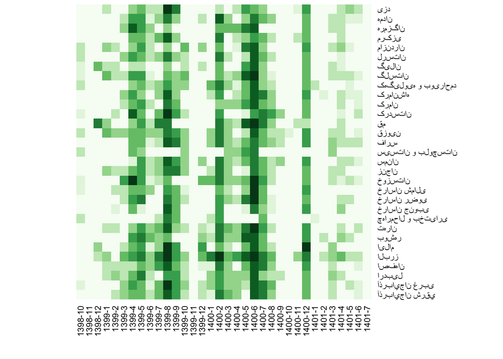

```r
col_names = c("1398-10", "1398-11", "1398-12", "1399-1", "1399-2",
                "1399-3", "1399-4", "1399-5", "1399-6", "1399-7",
                "1399-8", "1399-9", "1399-10", "1399-11", "1399-12",
                "1400-1", "1400-2", "1400-3", "1400-4", "1400-5", "1400-6", "1400-7",
                "1400-8", "1400-9", "1400-10", "1400-11", "1400-12",
                "1401-1", "1401-2", "1401-3", "1401-4", "1401-5", "1401-6", "1401-7")
colnames(res) = col_names
colnames(res_normal) = col_names
res_m <- as.matrix(res)
res_normal_m <- as.matrix(res_normal)

library(RColorBrewer)
heatmap(res_normal_m, col=brewer.pal(9, "Greens"), Colv = NA, Rowv = NA, scale="none")
```

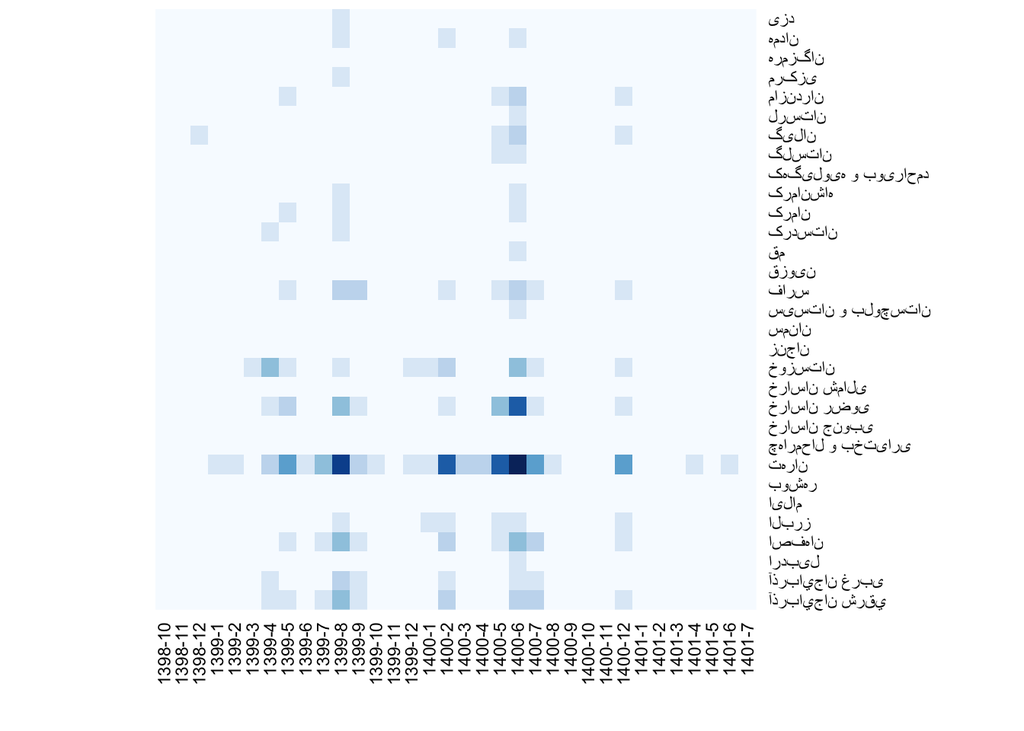

```r
heatmap(res_m, col=brewer.pal(9, "Blues"), Colv = NA, Rowv = NA, scale="none")
```

We can indicate a strong corona related excess mortality in 1399-4, 1399-8, 1400-2, 1400-6, 1400-12 it also seems that overal the peak in 1400-6 was stronger than others.

## Q2: total excess mortality in country?

For this, since the death rate is not same in every province, we can first calculate this in each province and then sum them all up.

```r
sum(unlist(res))
```

```
## [1] 304629
```

## Q3: total excess mortality of each province?

```r
row_sum = rowSums(res)
row_sum
```

```
##      آذربايجان شرقي      آذربايجان غربی              اردبیل              اصفهان
##               19049               14389                5549               21120
##               البرز               ایلام               بوشهر               تهران
##               15431                2011                3478               55388
##  چهارمحال و بختیاری        خراسان جنوبی         خراسان رضوی        خراسان شمالی
##                1356                1801               23636                2918
##             خوزستان               زنجان               سمنان   سیستان و بلوچستان
##               18681                4212                2651                4302
##                فارس               قزوین                  قم             کردستان
##               18169                5718                5693                6209
##               کرمان            کرمانشاه کهگیلویه و بویراحمد              گلستان
##                9120                8319                1904                7715
##               گیلان              لرستان            مازندران               مرکزی
##                8654                5813               11355                5056
##             هرمزگان               همدان                 یزد
##                3827                7529                3576
```

Also we can view it sorted

```r
sort(row_sum)
```

```
##  چهارمحال و بختیاری        خراسان جنوبی کهگیلویه و بویراحمد               ایلام
##                1356                1801                1904                2011
##               سمنان        خراسان شمالی               بوشهر                 یزد
##                2651                2918                3478                3576
##             هرمزگان               زنجان   سیستان و بلوچستان               مرکزی
##                3827                4212                4302                5056
##              اردبیل                  قم               قزوین              لرستان
##                5549                5693                5718                5813
##             کردستان               همدان              گلستان            کرمانشاه
##                6209                7529                7715                8319
##               گیلان               کرمان            مازندران      آذربايجان غربی
##                8654                9120               11355               14389
##               البرز                فارس             خوزستان      آذربايجان شرقي
##               15431               18169               18681               19049
##              اصفهان         خراسان رضوی               تهران
##               21120               23636               55388
```

```r
dsa = d[ym_num < ym_num_covid] # this is for Q4
dsa = dsa[, .(n = sum(n)), .(age_group)]# sum the total death based on age groups
dsa
```

```
##     age_group      n
##  1:         0 124340
##  2:     01-04  79579
##  3:     05-09  41240
##  4:     10-14  31420
##  5:     15-19  58359
##  6:     20-24  84218
##  7:     25-29  95303
##  8:     30-34  94134
##  9:     35-39  87388
## 10:     40-44  92630
## 11:     45-49 112585
## 12:     50-54 147192
## 13:     55-59 193213
## 14:     60-64 226757
## 15:     65-69 251620
## 16:     70-74 303085
## 17:     75-79 408439
## 18:     80-84 477274
## 19:     85-89 395243
## 20:     90-94 185361
## 21:       95+  58450
##     age_group      n
```

```r
1/dsa$n * dsa$n
```

```
##  [1] 1 1 1 1 1 1 1 1 1 1 1 1 1 1 1 1 1 1 1 1 1
```

```r
res <- as.data.frame(matrix(0, nrow = 31, ncol = 34)) #result Q1 data frame
res_normal <- as.data.frame(matrix(0, nrow = 31, ncol = 34)) #noraml result (as described)
rownames(res) = provinces
rownames(res_normal) = provinces
colnames(res) = months
colnames(res_normal) = months
ds = d[, .(n = sum(n)), .(y, m, ym_num, prov, age_group)]
res4 <- as.data.frame(matrix(0, nrow = 31, ncol = 1)) #result Q4 data frame
for(prov_ind in c(1:31)){
  for(month_ind in c(1:12)){
    province = provinces[prov_ind]
    dsm = ds[prov == province & m == month_ind,]
    dsm = dsm[ym_num > ym_num_start]
    dsm2fit = dsm[ym_num < ym_num_covid]
    # fit the linear model on the years before corona
    fit = lm(n ~ ym_num, dsm2fit)

    # pull out p-value from a linear model
    f <- summary(fit)$fstatistic
    p_value <- pf(f[1],f[2],f[3],lower.tail=F) # p-value
    attributes(p_value) <- NULL

    # if p_value is larger than 0.05 it means we are not certain so we are going to use mean value of model
    if(p_value > 0.05){
      dsm$expected = mean(dsm2fit$n) + 2*sd(dsm2fit$n)[1]
      sd = sd(dsm2fit$n)[1]
    }else{
      dsm$expected = predict(fit ,dsm) + 2*summary(fit)$sigma
      sd = summary(fit)$sigma
    }
    dsm$difference = dsm$n - dsm$expected
    dsm$difference[dsm$difference<0] = 0
    # for outliers which indicate the excess mortality, we are going to add an extra 2*sd since we subtracted it in two lines above
    dsm$difference[dsm$difference>0] = dsm$difference[dsm$difference>0] + 2*sd
    dsm$difference_normal = dsm$difference / dsm$n

    dsm_res = dsm[ym_num >= ym_num_covid]


    dsma = dsm_res[, .(n = sum(n)), .(age_group)]

    res4[prov_ind,1] = res4[prov_ind,1] + sum(dsma$n * (1/dsa$n))
  }
}
provinces
```

```
##  [1] "آذربايجان شرقي"      "آذربايجان غربی"      "اردبیل"
##  [4] "اصفهان"              "البرز"               "ایلام"
##  [7] "بوشهر"               "تهران"               "چهارمحال و بختیاری"
## [10] "خراسان جنوبی"        "خراسان رضوی"         "خراسان شمالی"
## [13] "خوزستان"             "زنجان"               "سمنان"
## [16] "سیستان و بلوچستان"   "فارس"                "قزوین"
## [19] "قم"                  "کردستان"             "کرمان"
## [22] "کرمانشاه"            "کهگیلویه و بویراحمد" "گلستان"
## [25] "گیلان"               "لرستان"              "مازندران"
## [28] "مرکزی"               "هرمزگان"             "همدان"
## [31] "یزد"
```

```r
res4
```

```
##            V1
## 1  0.42769506
## 2  0.31130429
## 3  0.13429739
## 4  0.45948558
## 5  0.23130838
## 6  0.05024548
## 7  0.08810095
## 8  1.11345647
## 9  0.07889240
## 10 0.07123470
## 11 0.60580422
## 12 0.08445327
## 13 0.45875749
## 14 0.09965102
```

[output cut: 17 more lines]

```r
ds = d[, .(n = sum(n)), .(y, m, ym_num, prov, age_group)]
ds = ds[ds$age_group<18]
res4 <- as.data.frame(matrix(0, nrow = 31, ncol = 1)) #result Q4 data frame
for(prov_ind in c(1:31)){
  for(month_ind in c(1:12)){
    province = provinces[prov_ind]
    dsm = ds[prov == province & m == month_ind,]
    dsm = dsm[ym_num > ym_num_start]
    dsm2fit = dsm[ym_num < ym_num_covid]
    # fit the linear model on the years before corona
    fit = lm(n ~ ym_num, dsm2fit)

    # pull out p-value from a linear model
    f <- summary(fit)$fstatistic
    p_value <- pf(f[1],f[2],f[3],lower.tail=F) # p-value
    attributes(p_value) <- NULL

    # if p_value is larger than 0.05 it means we are not certain so we are going to use mean value of model
    if(p_value > 0.05){
      dsm$expected = mean(dsm2fit$n) + 2*sd(dsm2fit$n)[1]
      sd = sd(dsm2fit$n)[1]
    }else{
      dsm$expected = predict(fit ,dsm) + 2*summary(fit)$sigma
      sd = summary(fit)$sigma
    }
    dsm$difference = dsm$n - dsm$expected
    dsm$difference[dsm$difference<0] = 0
    # for outliers which indicate the excess mortality, we are going to add an extra 2*sd since we subtracted it in two lines above
    dsm$difference[dsm$difference>0] = dsm$difference[dsm$difference>0] + 2*sd
    dsm$difference_normal = dsm$difference / dsm$n

    dsm_res = dsm[ym_num >= ym_num_covid]


    dsma = dsm_res[, .(n = sum(n)), .(age_group)]

    res4[prov_ind,1] = res4[prov_ind,1] + sum(dsma$n * (1/dsa$n))
  }
}
```

[output not shown]

[output cut: 1060 more lines]

[output not shown]

```r
provinces
```

```
##  [1] "آذربايجان شرقي"      "آذربايجان غربی"      "اردبیل"
##  [4] "اصفهان"              "البرز"               "ایلام"
##  [7] "بوشهر"               "تهران"               "چهارمحال و بختیاری"
## [10] "خراسان جنوبی"        "خراسان رضوی"         "خراسان شمالی"
## [13] "خوزستان"             "زنجان"               "سمنان"
## [16] "سیستان و بلوچستان"   "فارس"                "قزوین"
## [19] "قم"                  "کردستان"             "کرمان"
## [22] "کرمانشاه"            "کهگیلویه و بویراحمد" "گلستان"
## [25] "گیلان"               "لرستان"              "مازندران"
## [28] "مرکزی"               "هرمزگان"             "همدان"
## [31] "یزد"
```

```r
res4
```

```
##            V1
## 1  0.17127195
## 2  0.12365068
## 3  0.06136954
## 4  0.14259675
## 5  0.05769843
## 6  0.01874185
## 7  0.03601496
## 8  0.27025352
## 9  0.03050777
## 10 0.03643551
## 11 0.29584144
## 12 0.04018274
## 13 0.25910802
## 14 0.04464738
```

[output cut: 17 more lines]

```r
ds = d[, .(n = sum(n)), .(y, m, ym_num, prov, age_group)]
ds = ds[ds$age_group<18]
ds = d[, .(n = sum(n)), .(y, m, ym_num, prov)]
res <- as.data.frame(matrix(0, nrow = 31, ncol = 34)) #result Q1 data frame
res_normal <- as.data.frame(matrix(0, nrow = 31, ncol = 34)) #noraml result (as described)
rownames(res) = provinces
rownames(res_normal) = provinces
colnames(res) = months
colnames(res_normal) = months

for(prov_ind in c(1:31)){
  for(month_ind in c(1:12)){
    province = provinces[prov_ind]

    dsm = ds[prov == province & m == month_ind,]
    dsm = dsm[ym_num > ym_num_start]
    dsm2fit = dsm[ym_num < ym_num_covid]
    # fit the linear model on the years before corona
    fit = lm(n ~ ym_num, dsm2fit)

    # pull out p-value from a linear model
    f <- summary(fit)$fstatistic
    p_value <- pf(f[1],f[2],f[3],lower.tail=F) # p-value
    attributes(p_value) <- NULL

    # if p_value is larger than 0.05 it means we are not certain so we are going to use mean value of model
    if(p_value > 0.05){
      dsm$expected = mean(dsm2fit$n) + 2*sd(dsm2fit$n)[1]
      sd = sd(dsm2fit$n)[1]
    }else{
      dsm$expected = predict(fit ,dsm) + 2*summary(fit)$sigma
      sd = summary(fit)$sigma
    }
    dsm$difference = dsm$n - dsm$expected
    dsm$difference[dsm$difference<0] = 0
    # for outliers which indicate the excess mortality, we are going to add an extra 2*sd since we subtracted it in two lines above
    dsm$difference[dsm$difference>0] = dsm$difference[dsm$difference>0] + 2*sd
    dsm$difference_normal = dsm$difference / dsm$n

    dsm_res = dsm[ym_num >= ym_num_covid]
    for (i in unique(dsm_res$ym_num)) {
      res[province,as.character(i)] = as.integer(round(dsm_res[ym_num==i]$difference))
      res_normal[province,as.character(i)] = dsm_res[ym_num==i]$difference_normal[1]
    }

  }
}
```

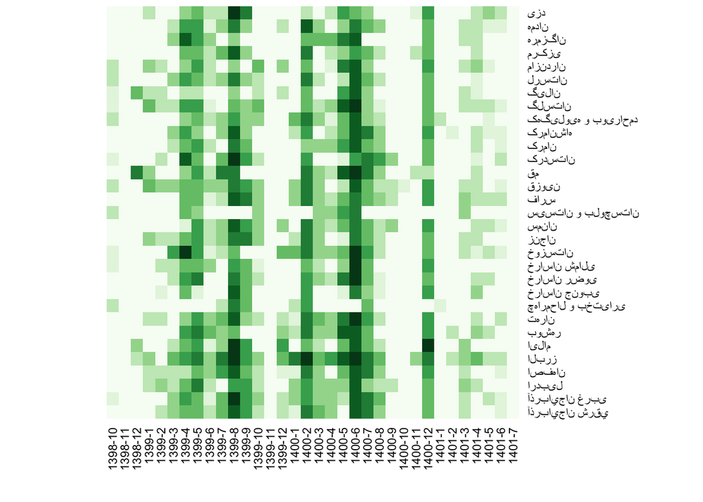

```r
col_names = c("1398-10", "1398-11", "1398-12", "1399-1", "1399-2",
                "1399-3", "1399-4", "1399-5", "1399-6", "1399-7",
                "1399-8", "1399-9", "1399-10", "1399-11", "1399-12",
                "1400-1", "1400-2", "1400-3", "1400-4", "1400-5", "1400-6", "1400-7",
                "1400-8", "1400-9", "1400-10", "1400-11", "1400-12",
                "1401-1", "1401-2", "1401-3", "1401-4", "1401-5", "1401-6", "1401-7")
colnames(res) = col_names
colnames(res_normal) = col_names
res_m <- as.matrix(res)
res_normal_m <- as.matrix(res_normal)

library(RColorBrewer)
heatmap(res_normal_m, col=brewer.pal(9, "Greens"), Colv = NA, Rowv = NA, scale="none")
```

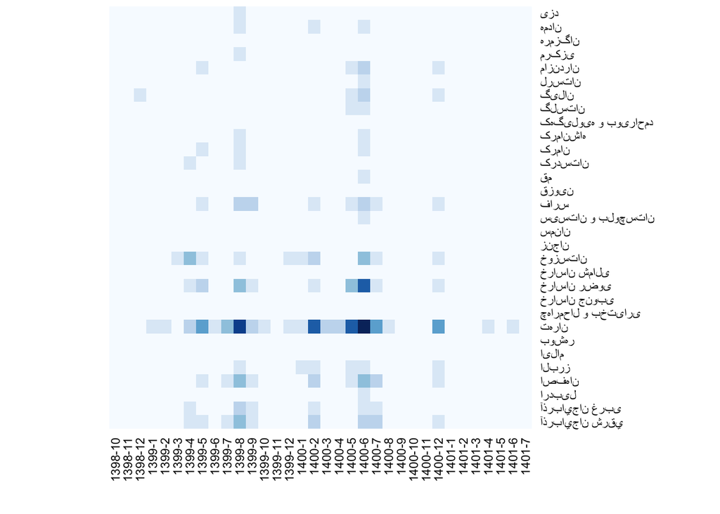

```r
heatmap(res_m, col=brewer.pal(9, "Blues"), Colv = NA, Rowv = NA, scale="none")
```

```r
row_sum = rowSums(res)
sort(row_sum)
```

```
##  چهارمحال و بختیاری        خراسان جنوبی کهگیلویه و بویراحمد               ایلام
##                1356                1801                1904                2011
##               سمنان        خراسان شمالی               بوشهر                 یزد
##                2651                2918                3478                3576
##             هرمزگان               زنجان   سیستان و بلوچستان               مرکزی
##                3827                4212                4302                5056
##              اردبیل                  قم               قزوین              لرستان
##                5549                5693                5718                5813
##             کردستان               همدان              گلستان            کرمانشاه
##                6209                7529                7715                8319
##               گیلان               کرمان            مازندران      آذربايجان غربی
##                8654                9120               11355               14389
##               البرز                فارس             خوزستان      آذربايجان شرقي
##               15431               18169               18681               19049
##              اصفهان         خراسان رضوی               تهران
##               21120               23636               55388
```